# Lab 1: Intro to R

Preston Peck

2021-09-05

# Introduction to R and RStudio

https://htmlpreview.github.io/?https://github.com/jbryer/DATA606/blob/master/inst/labs/Lab1/Lab1_intro_to_r.html

```r
library(tidyverse)
library(openintro)
```

### Exercise 1

```r
arbuthnot$girls
```

```
##  [1] 4683 4457 4102 4590 4839 4820 4928 4605 4457 4952 4784 5332 5200 4910 4617
## [16] 3997 3919 3395 3536 3181 2746 2722 2840 2908 2959 3179 3349 3382 3289 3013
## [31] 2781 3247 4107 4803 4881 5681 4858 4319 5322 5560 5829 5719 6061 6120 5822
## [46] 5738 5717 5847 6203 6033 6041 6299 6533 6744 7158 7127 7246 7119 7214 7101
## [61] 7167 7302 7392 7316 7483 6647 6713 7229 7767 7626 7452 7061 7514 7656 7683
## [76] 5738 7779 7417 7687 7623 7380 7288
```

### Exercise 2

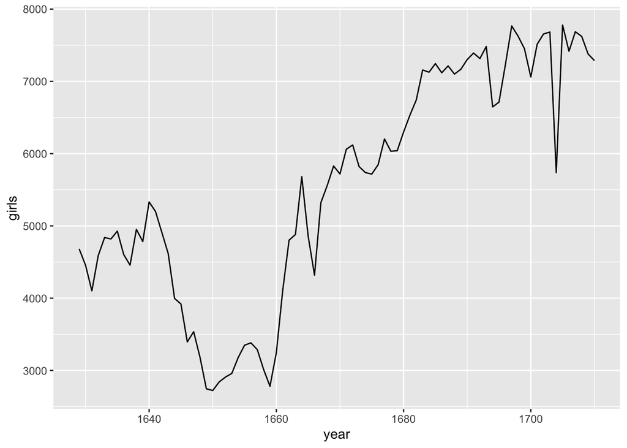

```r
ggplot(data = arbuthnot, aes(x = year, y = girls)) + geom_line()
```

### Exercise 3

The percentage of babies that are boys being baptized understandably slightly fluctuates around 50% over the years. This would make sense being that half of the world’s population is male

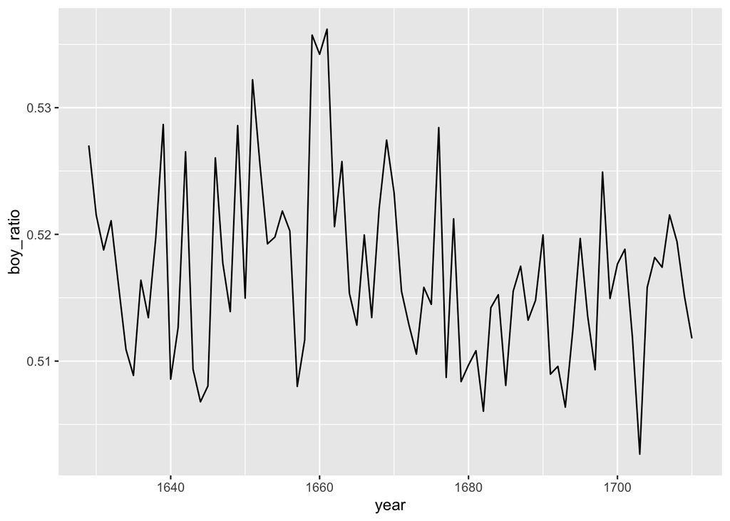

```r
arbuthnot <- arbuthnot %>%
  mutate(total = boys + girls)

arbuthnot <- arbuthnot %>%
  mutate(boy_ratio = boys / total)

ggplot(data = arbuthnot, aes(x = year, y = boy_ratio)) + geom_line()
```

### Exercise 4

The present data frame has data between and including the years 1940 to 2002 The present frame has 63 rows and 3 columns The present frame columns are year, number of boys, and number of girls

```r
present$year
```

```
##  [1] 1940 1941 1942 1943 1944 1945 1946 1947 1948 1949 1950 1951 1952 1953 1954
## [16] 1955 1956 1957 1958 1959 1960 1961 1962 1963 1964 1965 1966 1967 1968 1969
## [31] 1970 1971 1972 1973 1974 1975 1976 1977 1978 1979 1980 1981 1982 1983 1984
## [46] 1985 1986 1987 1988 1989 1990 1991 1992 1993 1994 1995 1996 1997 1998 1999
## [61] 2000 2001 2002
```

```r
arbuthnot$year
```

```
##  [1] 1629 1630 1631 1632 1633 1634 1635 1636 1637 1638 1639 1640 1641 1642 1643
## [16] 1644 1645 1646 1647 1648 1649 1650 1651 1652 1653 1654 1655 1656 1657 1658
## [31] 1659 1660 1661 1662 1663 1664 1665 1666 1667 1668 1669 1670 1671 1672 1673
## [46] 1674 1675 1676 1677 1678 1679 1680 1681 1682 1683 1684 1685 1686 1687 1688
## [61] 1689 1690 1691 1692 1693 1694 1695 1696 1697 1698 1699 1700 1701 1702 1703
## [76] 1704 1705 1706 1707 1708 1709 1710
```

```r
dim(present)
```

```
## [1] 63  3
```

```r
names(present)
```

```
## [1] "year"  "boys"  "girls"
```

### Exercise 5

```r
present <- present %>%
  mutate(total = boys + girls)

compareDataFrames <- data.frame(
  boys = rep(NA, 2),
  girls = rep(NA, 2),
  total = rep(NA, 2),
  boys_ratio = rep(NA, 2)
)

compareDataFrames[1,] <- c(
  colSums(arbuthnot[,c(-1,-5)]),
  sum(arbuthnot$boys) / sum(arbuthnot$total)
)

compareDataFrames[2,] <- c(
  colSums(present[,-1]),
  sum(present$boys) / sum(present$total)
)

rownames(compareDataFrames) <- c("arbuthnot", "present")
compareDataFrames
```

```
##                boys     girls     total boys_ratio
## arbuthnot    484382    453841    938223  0.5162760
## present   118792776 113016646 231809422  0.5124588
```

```r
presentToArbuthnotTotalRatio <- compareDataFrames$total[2] / compareDataFrames$total[1]
presentToArbuthnotTotalRatio
```

```
## [1] 247.0728
```

### Exercise 6

Arbuthnot’s observation about boys being born in greater proportion than girls still holds up in the U.S being that for every year in the birth set, the percentage of boys being born remained over 50%

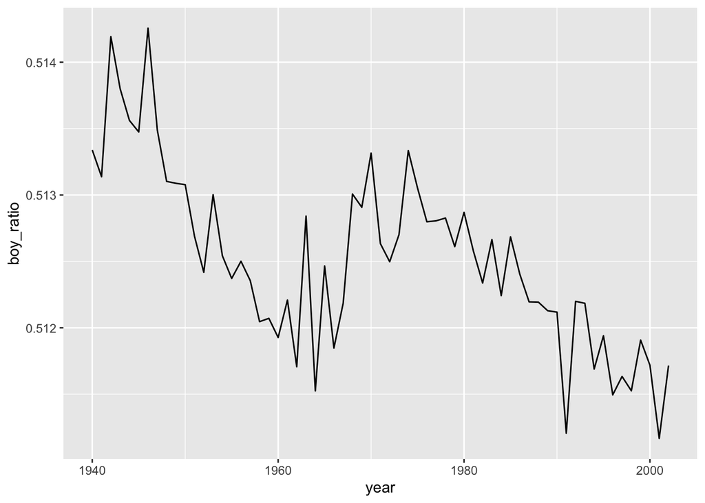

```r
present <- present %>%
  mutate(boy_ratio = boys / total)

ggplot(data = present, aes(x = year, y = boy_ratio)) + geom_line()
```

### Exercise 7

The year with the most births in the U.S. was 1961

```r
totals <- rbind(arbuthnot[,c(1,4)], present[,c(1,4)])

totals %>%
  arrange(desc(total))
```

```
## # A tibble: 145 × 2
##     year   total
##    <dbl>   <dbl>
##  1  1961 4268326
##  2  1960 4257850
##  3  1957 4254784
##  4  1959 4244796
##  5  1958 4203812
##  6  1962 4167362
##  7  1956 4163090
##  8  1990 4158212
##  9  1991 4110907
## 10  1963 4098020
## # … with 135 more rows
```

```r
maxTotal <- totals[which.max(totals$total),]
maxTotal
```

```
## # A tibble: 1 × 2
##    year   total
##   <dbl>   <dbl>
## 1  1961 4268326
```